# Gray Rockfish

*Sebastes glaucus*

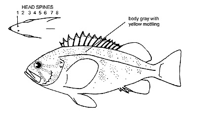

**Body color:** Black to gray w/ yellow mottling; three dark bars radiate posteriorly from eye.

**Peritoneum color:** dark **Shape between eyes:** convex

**Counts:** D:XIV,14-17, Ar:7-9, P1:18-20, GR:34-41, LLp:37-52, LLs:48-78, V:29-30

**Occurence:** Aleutian Islands

**Depth:** 550 meters **Size:** 50 cm **Species code:** 30255

**Similar species:**

- *Dusky rockfish* - body tan to dark blue-black; symphyseal knob moderate to small (symphyseal knob absent in Gray RF); pectoral rays typically 18 (typically 19 in Gray RF)
- *Black rockfish* - body black to gray, white ventrally; body slender (robust in Gray RF); head spine count differs; peritoneum typically light; head spine count typically differs
- *Yellowtail rockfish* - symphyseal knob strong (absent in Gray RF); peritoneum light

Back to Group

**Corrections:** If you see mistakes or want to suggest changes, please create an [issue](https://github.com/zoyafuso-NOAA/RACE_Survey_App/issues) on the source repository or

*reach out to Liz Dawson (Liz.Dawson AT noaa.gov).*